# Intro to visualization in R

And Grammar of Graphics!

25/5/2022

## R and graphs

- simple to use but strong graphical system
- vector based - crisp, resizable, multiformat
- from simple charts to online interactive graphical dashboards

## Why is visualization important?

- famous Anscombe’s Quartet
- 4 pairs of X-Y variables
- Same mean(x), sd(x), mean(y), sd(y), cor(x,y)

## Why is visualization important?

|  | n | mean | sd |
| --- | --- | --- | --- |
| x1 | 11 | 9.0 | 3.32 |
| x2 | 11 | 9.0 | 3.32 |
| x3 | 11 | 9.0 | 3.32 |
| x4 | 11 | 9.0 | 3.32 |
| y1 | 11 | 7.5 | 2.03 |
| y2 | 11 | 7.5 | 2.03 |
| y3 | 11 | 7.5 | 2.03 |
| y4 | 11 | 7.5 | 2.03 |

## Why is visualization important?

[figure not shown]

## Why is visualization important?

- summary statistics can deceive!
- Exploratory data analyses (Tukey, 1977):
  - “This is my favorite part about analytics: Taking boring flat data and bringing it to life through visualization.”
  - “There is no data that can be displayed in a pie chart, that cannot be displayed better in some other type of chart.”

## Grammar of graphics

- Wilkinson (1999)
  - framework which structures the process of describing and constructing visualizations or graphs
- Wickham (2010)
  - layered grammar of graphics - use layers to construct multidimensional graphs
  - “A grammar provides a strong foundation for understanding a diverse range of graphics”

## ggplot

- a grammar of graphics implementation
- graphs as objects
- combining layers one on top of the other
- saving intermediate steps and building branching graphs

## layered grammar of graphics

- data (raw data)
- layer
  - data & mapping (from data to aesthetics)
  - stat (statistical transformation; i.e. percentage or regression line)
  - geom (type of graph, geometrical representation)
  - position (position adjustment to prevent overlap)
- scale (controls the mapping of data to aes)
- coordinates (ticks, annotations, title etc.)
- facets (multiple graphs that share the above by group members)

## data and mapping (data and aes)

- data independent of other aspects of graph (reusability)
- aes (aesthetics) - which variables are mapped to which aesthetic (x, y, color…)

## statistical transformation (stat)

- example:
  - smooth (calculates the mean of y, conditional on x)
- stat takes a dataset as input and returns a dataset as output (stat can add new variables to the original dataset)

## geometric objects (geom)

- abstract component and can be rendered in different ways
- example:
  - histogram
    - raw vs. summary (stat=“identity”)
  - point
    - jitter, alpha and size
  - boxplot
    - multiple variables with same scale
  - scatterplot
    - jitter, alpha, size

## scale

- controls the mapping from data to aesthetic attributes
- scales are common across layers to ensure a consistent mapping from data to aesthetics

## scale

Wickham (2010)

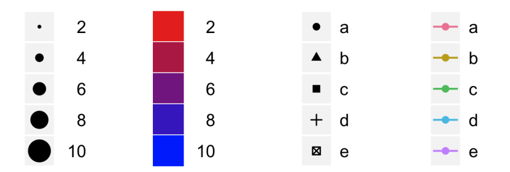

## Variables and charts

## Variable types

- extremely important for the purpose of visualization
- to understand the metrics, behavior and meaning of variables
- allows us to pick the right tool for visualization

## Overlaping categories

- quantitative vs. qualitative
- continuous vs. discreet
- categorical vs continuous

## S.S. Stevens (1946)

- nominal - categories or labels
- ordinal - object ranking, ordered categories
- interval - distance between objects known
- scale - have a meaningful absolute zero

## S.S. Stevens in R

- nominal (factor with k levels)
- ordinal (ordered factor with k levels)
- interval (numerical: integer or float/double)
- scale (numerical: integer or float/double)

## What can we do in ggplot?